# IODS course project

Sami Muraja

# Introduction to Open Data Science - Course Project

Last updated:

```r
date()
```

```
## [1] "Tue Dec 13 13:14:52 2022"
```

## About the project

This is my learning diary for the course Introduction to Open Data Science. I’m expecting to get a better grasp of how to started analyzing data and to learn to write more readable code. I hope that after this course my thoughts will be less all over the place and will instead have a structure of some sort in my mind that helps me tie those thoughts together. You can find my Github repository for this project here: https://github.com/muraja/IODS-project.git

I find the course book [R for Health Data Science](https://argoshare.is.ed.ac.uk/healthyr_book/) readable and useful. I noticed having a tendency to read too closely, wanting to make sure I understand all the code instead of just skimming the first chapters quickly through, so I took longer with the first chapters than I intended. I think it it might have been more time-efficient to skim them through quickly now and coming back later when doing the exercises, but it still felt helpful: it clarified some of the confusion I’ve experienced when facing errors in my code (even those I resolved), and I got ideas for writing better, more readable and concise code. I’ve found dplyr functions a bit more confusing than traditional R when they have come up in forum answers, but reading through the first chapters made me more comfortable with this style. Now I’m curious to learn more and to get to write some new code.

I’m used to writing in markdown and I’m quite fond of it, so testing Rmd has been very pleasing. I enjoyed starting the course with the exercise set in Rmd format. Having learned how Github works, I realized that when I need or want to share my writing, writing in RStudio and publishing in Github could be a very handy and familiar way of doing that - even if it was just text. I wish I realized to do that earlier. Rmd also makes writing *about* code quite delightful as pleasantly readable text can be written with embedded working code blocks. I should have tried it sooner! More ways to avoid using Word are always welcome.

# Linear Regression & Model Validation

This week I practiced linear regression and studied its assumptions and their validation via diagnostic plots to better understand how it works and how it should be used correctly. Here I present the data used, graphs for understanding the data, regression model summaries, and finally, diagnostic plots for validating the use of the model.

#### The data

```r
# loading the dataset
library(tidyverse)
l14 <- read_csv("C:/Users/SM/Documents/IODS-project/data/learning2014.csv")
# inspecting the data
l14 # viewing the data table
```

```
## # A tibble: 166 x 7
##    gender   age attitude  deep  stra  surf points
##    <chr>  <dbl>    <dbl> <dbl> <dbl> <dbl>  <dbl>
##  1 F         53      3.7  3.58  3.38  2.58     25
##  2 M         55      3.1  2.92  2.75  3.17     12
##  3 F         49      2.5  3.5   3.62  2.25     24
##  4 M         53      3.5  3.5   3.12  2.25     10
##  5 M         49      3.7  3.67  3.62  2.83     22
##  6 F         38      3.8  4.75  3.62  2.42     21
##  7 M         50      3.5  3.83  2.25  1.92     21
##  8 F         37      2.9  3.25  4     2.83     31
##  9 M         37      3.8  4.33  4.25  2.17     24
## 10 F         42      2.1  4     3.5   3        26
## # ... with 156 more rows
```

```r
dim(l14) # dimensions of the dataset
```

```
## [1] 166   7
```

```r
str(l14) # structure of the dataset
```

```
## spec_tbl_df [166 x 7] (S3: spec_tbl_df/tbl_df/tbl/data.frame)
##  $ gender  : chr [1:166] "F" "M" "F" "M" ...
##  $ age     : num [1:166] 53 55 49 53 49 38 50 37 37 42 ...
##  $ attitude: num [1:166] 3.7 3.1 2.5 3.5 3.7 3.8 3.5 2.9 3.8 2.1 ...
##  $ deep    : num [1:166] 3.58 2.92 3.5 3.5 3.67 ...
##  $ stra    : num [1:166] 3.38 2.75 3.62 3.12 3.62 ...
##  $ surf    : num [1:166] 2.58 3.17 2.25 2.25 2.83 ...
##  $ points  : num [1:166] 25 12 24 10 22 21 21 31 24 26 ...
##  - attr(*, "spec")=
##   .. cols(
##   ..   gender = col_character(),
##   ..   age = col_double(),
##   ..   attitude = col_double(),
##   ..   deep = col_double(),
##   ..   stra = col_double(),
##   ..   surf = col_double(),
##   ..   points = col_double()
##   .. )
##  - attr(*, "problems")=<externalptr>
```

This dataset has 7 variables, one of which is categorical (gender) and 6 of which are numerical. The variables *deep*, *stra* and *surf* refer to learning methods. The variable *points* refer to exam score, which is the outcome variable of this dataset.

Next, let’s plot a graph to better understand the data.

#### Graphical overview

```r
library(GGally)
```

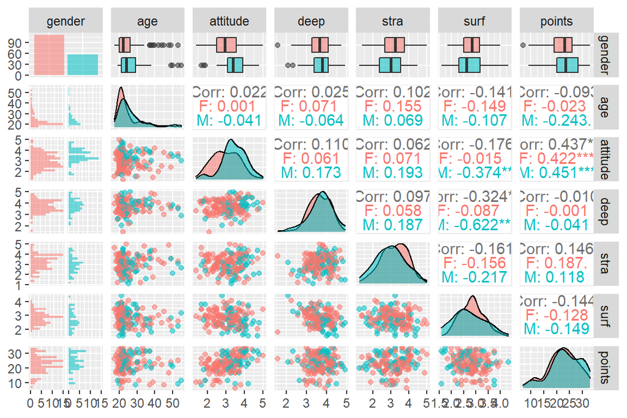

```r
library(ggplot2)

# creating a plot matrix
p <- ggpairs(l14,
             mapping = aes(col = gender, alpha = 0.3),
             lower = list(combo = wrap("facethist", bins = 20)))
p
```

From the graph we learn that *attitude* is moderately correlated with *points*, whereas the correlations of the other variables with *points* are very weak. The demography of the sample is young and mostly female. The correlation between learning strategy variables *deep* and *surf* is large enough that one should beware of it if including both variables in the same linear regression model as collinearity can make the coefficients unstable.

```r
# summary of the variable data
summary(l14)
```

```
##     gender               age           attitude          deep
##  Length:166         Min.   :17.00   Min.   :1.400   Min.   :1.583
##  Class :character   1st Qu.:21.00   1st Qu.:2.600   1st Qu.:3.333
##  Mode  :character   Median :22.00   Median :3.200   Median :3.667
##                     Mean   :25.51   Mean   :3.143   Mean   :3.680
##                     3rd Qu.:27.00   3rd Qu.:3.700   3rd Qu.:4.083
##                     Max.   :55.00   Max.   :5.000   Max.   :4.917
##       stra            surf           points
##  Min.   :1.250   Min.   :1.583   Min.   : 7.00
##  1st Qu.:2.625   1st Qu.:2.417   1st Qu.:19.00
##  Median :3.188   Median :2.833   Median :23.00
##  Mean   :3.121   Mean   :2.787   Mean   :22.72
##  3rd Qu.:3.625   3rd Qu.:3.167   3rd Qu.:27.75
##  Max.   :5.000   Max.   :4.333   Max.   :33.00
```

#### Regression model

As we could see from the earlier graph p, the strongest correlations with points are with *attitude*, *stra* and *surf* so I’ll choose them as the 3 explanatory variables.

```r
model1 <- lm(points ~ attitude + stra + surf, data = l14)
summary(model1)
```

```
##
## Call:
## lm(formula = points ~ attitude + stra + surf, data = l14)
##
## Residuals:
##      Min       1Q   Median       3Q      Max
## -17.1550  -3.4346   0.5156   3.6401  10.8952
##
## Coefficients:
##             Estimate Std. Error t value Pr(>|t|)
## (Intercept)  11.0171     3.6837   2.991  0.00322 **
## attitude      3.3952     0.5741   5.913 1.93e-08 ***
## stra          0.8531     0.5416   1.575  0.11716
## surf         -0.5861     0.8014  -0.731  0.46563
## ---
## Signif. codes:  0 '***' 0.001 '**' 0.01 '*' 0.05 '.' 0.1 ' ' 1
##
## Residual standard error: 5.296 on 162 degrees of freedom
## Multiple R-squared:  0.2074, Adjusted R-squared:  0.1927
## F-statistic: 14.13 on 3 and 162 DF,  p-value: 3.156e-08
```

*Attitude* is the only variable that has a statistically significant relationship with the target variable *points*. I’ll remove the variable with the lowest t-score, *surf*, from the model.

```r
model2 <- lm(points ~ attitude + stra, data = l14)
summary(model2)
```

```
##
## Call:
## lm(formula = points ~ attitude + stra, data = l14)
##
## Residuals:
##      Min       1Q   Median       3Q      Max
## -17.6436  -3.3113   0.5575   3.7928  10.9295
##
## Coefficients:
##             Estimate Std. Error t value Pr(>|t|)
## (Intercept)   8.9729     2.3959   3.745  0.00025 ***
## attitude      3.4658     0.5652   6.132 6.31e-09 ***
## stra          0.9137     0.5345   1.709  0.08927 .
## ---
## Signif. codes:  0 '***' 0.001 '**' 0.01 '*' 0.05 '.' 0.1 ' ' 1
##
## Residual standard error: 5.289 on 163 degrees of freedom
## Multiple R-squared:  0.2048, Adjusted R-squared:  0.1951
## F-statistic: 20.99 on 2 and 163 DF,  p-value: 7.734e-09
```

The probability of the t-score of *stra* if the null hypothesis was true is still 0.08927, so I’m removing it from the model as well.

```r
model3 <- lm(points ~ attitude, data = l14)
summary(model3)
```

```
##
## Call:
## lm(formula = points ~ attitude, data = l14)
##
## Residuals:
##      Min       1Q   Median       3Q      Max
## -16.9763  -3.2119   0.4339   4.1534  10.6645
##
## Coefficients:
##             Estimate Std. Error t value Pr(>|t|)
## (Intercept)  11.6372     1.8303   6.358 1.95e-09 ***
## attitude      3.5255     0.5674   6.214 4.12e-09 ***
## ---
## Signif. codes:  0 '***' 0.001 '**' 0.01 '*' 0.05 '.' 0.1 ' ' 1
##
## Residual standard error: 5.32 on 164 degrees of freedom
## Multiple R-squared:  0.1906, Adjusted R-squared:  0.1856
## F-statistic: 38.61 on 1 and 164 DF,  p-value: 4.119e-09
```

The higher the *attitude* score, ie. the more positive attitude towards learning, the higher exam points can be expected. The multiple R<sup>2</sup> is 0.1906, which means that *attitude* explains about 19 % of the variation of exam *points*. It’s noteworthy that R<sup>2</sup> scores didn’t change much in removing the other explanatory variables, ie. the model with a single explanatory variable explains almost as much of the variance as a model with three explanatory variables. Therefore we can be confident about removing them.

#### Diagnostic plots

The linear regression model has the four following assumptions:

1. linear relationship between predictors and outcome
2. independence of residuals
3. normal distribution of residuals
4. equal variance of residuals

Next I’m testing these by plotting diagnostic plots: residuals vs fitted values, normal QQ-plot and residuals vs leverage.

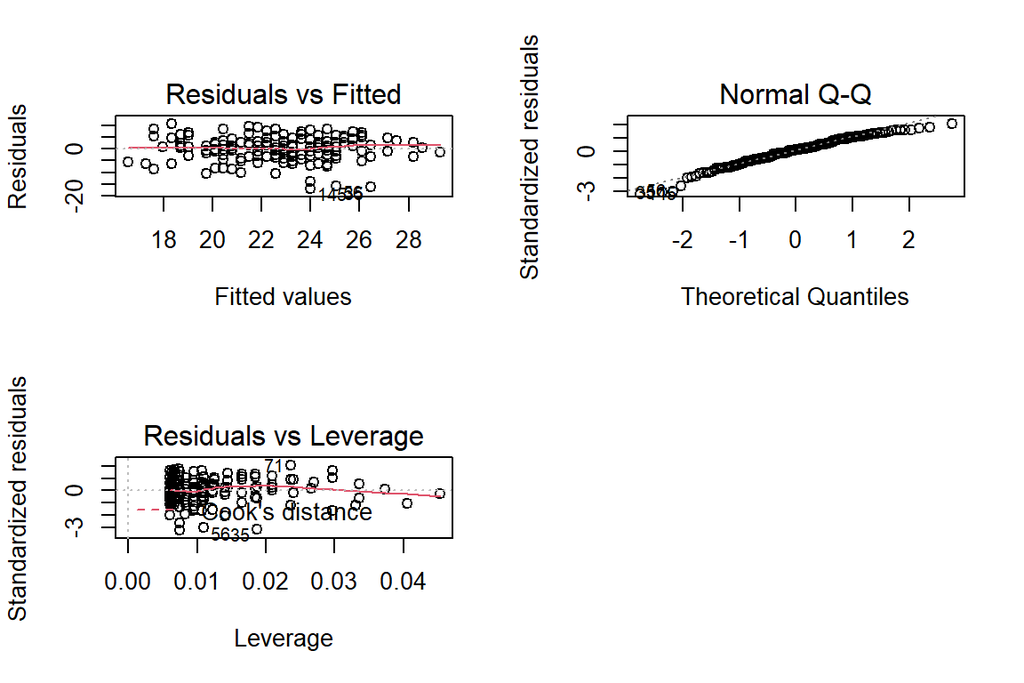

```r
par(mfrow = c(2,2))
model3 %>% plot(which = c(1,2,5))
```

In the **Residuals vs Fitted** plot the red line is close to the dashed line, so we can interpret that linearity holds pretty well. Heteroscedasticity (change of spread) seems mild.

In the **Q-Q Plot of Residuals** most of the observations are along the straight line, so we can assume that the dataset is normally distributed.

In the **Residuals vs Leverage** plot the leverage refers to how much the coefficients, in this case *attitude*, would change if the observation was removed. The leverages are small and none of the values fall within the cook’s distance, so there are no *influential points*. This means that there are no observations that would significantly change the model coefficients if removed.

Based on these diagnostic plots the linear regression model fits the data well.

# Logistic Regression

### The data

```r
library(tidyverse); library(ggplot2); library(readr)
alc <- read_csv("C:/Users/SM/Documents/IODS-project/data/alc.csv")
colnames(alc)
```

```
##  [1] "school"     "sex"        "age"        "address"    "famsize"
##  [6] "Pstatus"    "Medu"       "Fedu"       "Mjob"       "Fjob"
## [11] "reason"     "guardian"   "traveltime" "studytime"  "schoolsup"
## [16] "famsup"     "activities" "nursery"    "higher"     "internet"
## [21] "romantic"   "famrel"     "freetime"   "goout"      "Dalc"
## [26] "Walc"       "health"     "failures"   "paid"       "absences"
## [31] "G1"         "G2"         "G3"         "alc_use"    "high_use"
```

The data set in use was contains demographic attributes and exam scores in Math and Portuguese of students in two Portuguese schools. You can view the variables above and read more about the data [here](https://archive.ics.uci.edu/ml/datasets/Student+Performance).

The purpose of this analysis is to use this data to study the relationships of high and low consumption of alcohol with sex, age, freetime and address. Before the analysis, I present the following hypotheses about these relationships:

- sex: I expect more males to have high use of alcohol than females.
- age: I expect high alcohol use to peak at 18 years old as it’s the minimum age for legally selling alcohol outside restaurants in Portugal.
- freetime: I expect those with more free time to be more likely to have a high alcohol consumption.
- address: I expect more student living in urban areas to have a high alcohol use than those living in rural areas.

These hypotheses are not based on any data.

### Distributions of variables

Here I’ll visualize the distribution of the variables and their relationship to alcohol use using both graphical and numerical means.

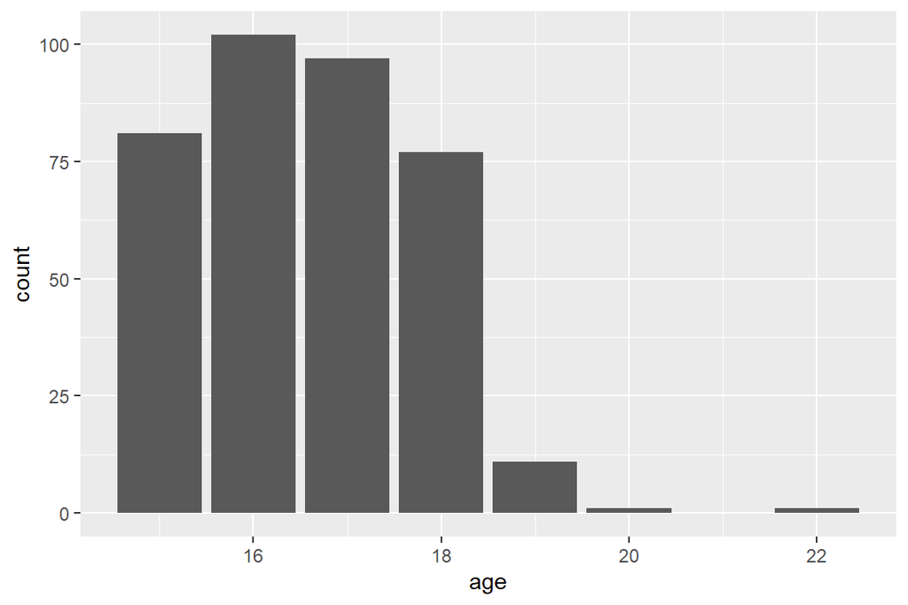

```r
# distribution of age
g_age <- alc %>% ggplot(aes(x = age))
g_age + geom_bar()
```

Just based on the age distribution alone my hypothesis is less plausible to be shown by this data as there is very little students above the age of 18 in this dataset.

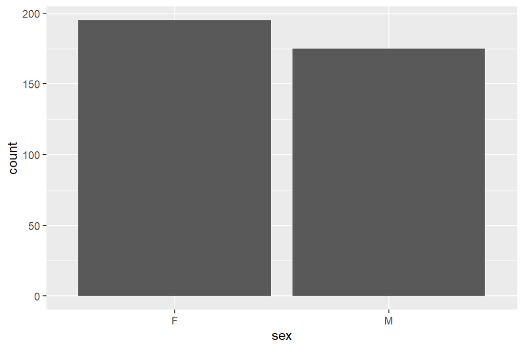

```r
# distribution of sex
g_sex <- alc %>% ggplot(aes(x = sex))
g_sex + geom_bar()
```

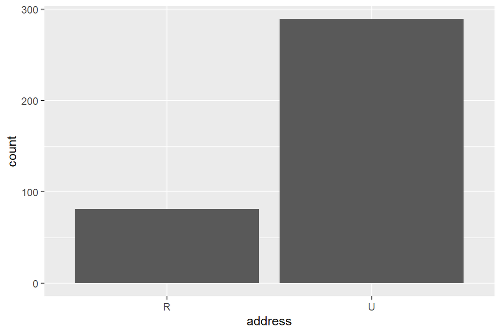

```r
# distribution of address
g_address <- alc %>% ggplot(aes(x = address))
g_address + geom_bar()
```

Most of the students live in urban areas.

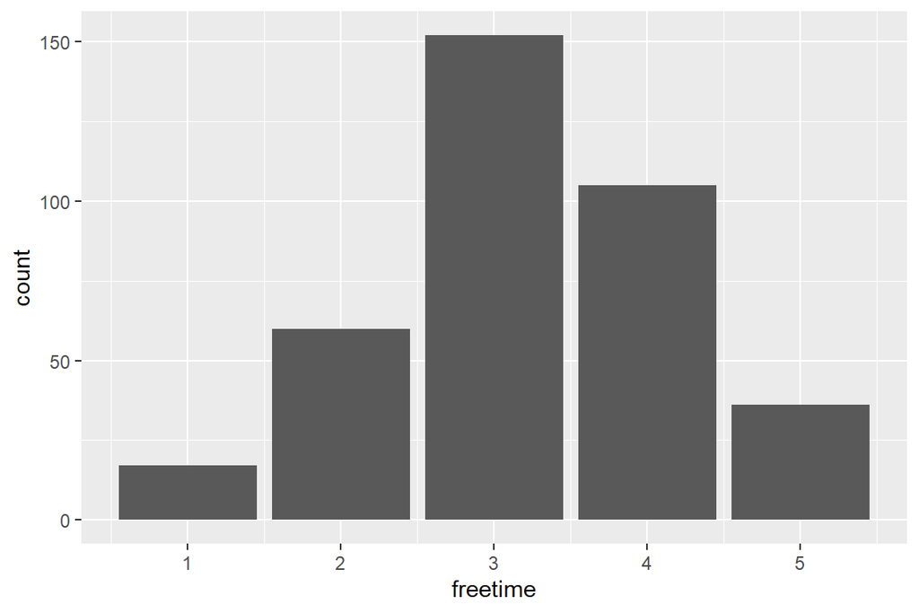

```r
# distribution of free time
g_freetime <- alc %>% ggplot(aes(x = freetime))
g_freetime + geom_bar()
```

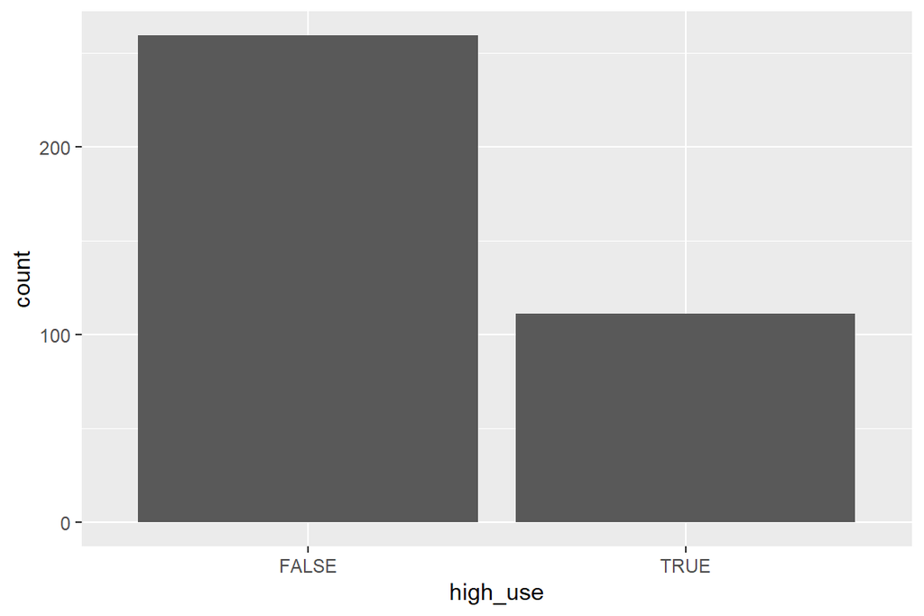

```r
# distribution of high alcohol use
g_high <- ggplot(data = alc, aes(x = high_use))
g_high + geom_bar()
```

Quite a lot of students have high alcohol consumption with the used criteria.

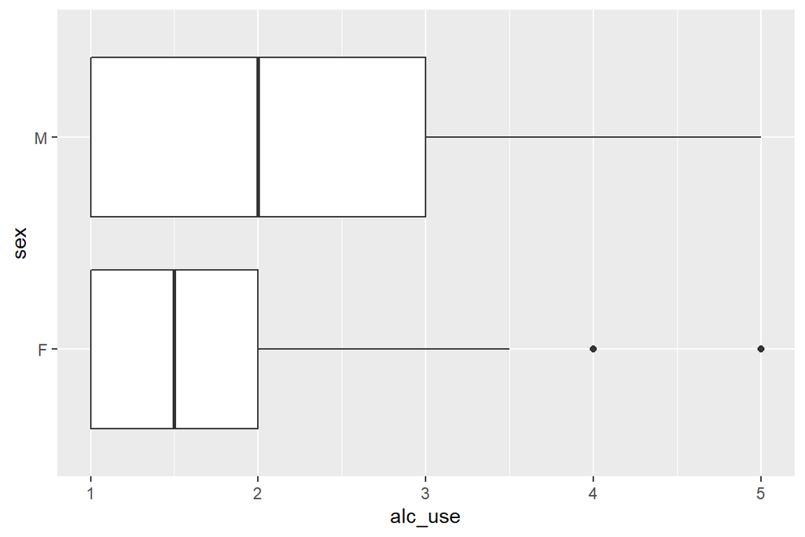

```r
# plotting alc_use and sex
gas <- ggplot(alc, aes(x = alc_use, y = sex))
gas + geom_boxplot()
```

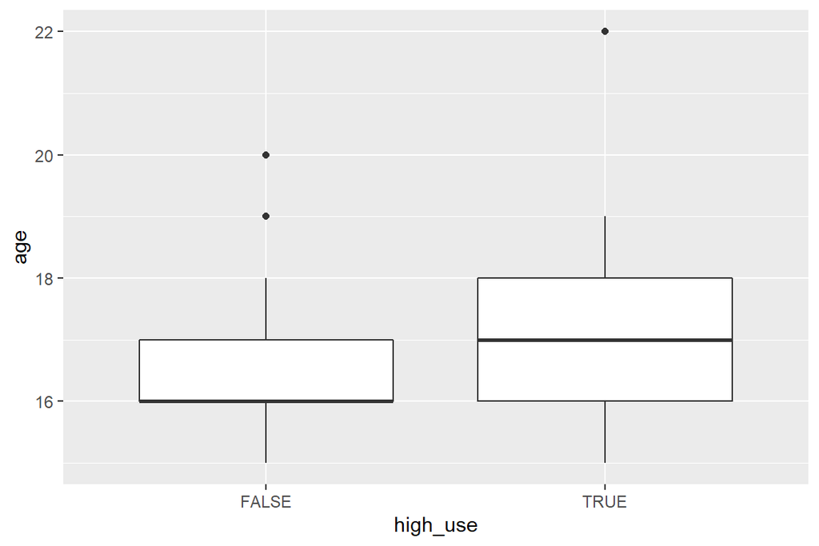

```r
# plotting a plot of high_use and age
gha <- ggplot(alc, aes(x = high_use, y = age))
gha + geom_boxplot()
```

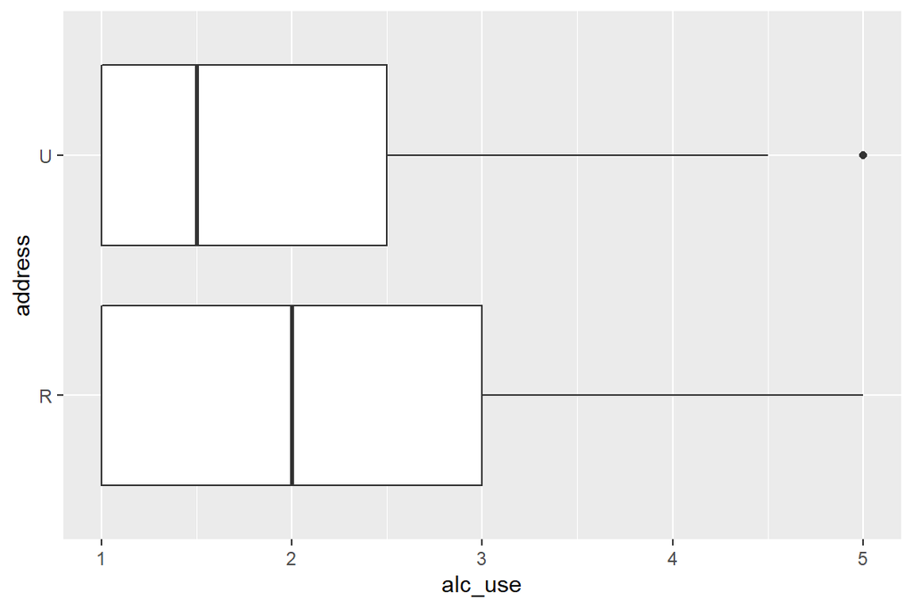

```r
# plotting alc_use and address
gaa <- ggplot(alc, aes(x = alc_use, y = address))
gaa + geom_boxplot()
```

Next, I’ll show numerical summaries split into two tables to limit the number of rows:

```r
# produce summary statistics by group
alc %>% group_by(address, high_use) %>% summarise(count = n(), age = mean(age), freetime = mean(freetime))
```

```
## # A tibble: 4 x 5
## # Groups:   address [2]
##   address high_use count   age freetime
##   <chr>   <lgl>    <int> <dbl>    <dbl>
## 1 R       FALSE       50  16.9     3.08
## 2 R       TRUE        31  17       3.26
## 3 U       FALSE      209  16.4     3.13
## 4 U       TRUE        80  16.7     3.55
```

```r
# produce summary statistics by group
alc %>% group_by(sex, high_use) %>% summarise(count = n(), age = mean(age), freetime = mean(freetime))
```

[output not shown]

```
## # A tibble: 4 x 5
## # Groups:   sex [2]
##   sex   high_use count   age freetime
##   <chr> <lgl>    <int> <dbl>    <dbl>
## 1 F     FALSE      154  16.6     2.93
## 2 F     TRUE        41  16.5     3.34
## 3 M     FALSE      105  16.3     3.4
## 4 M     TRUE        70  16.9     3.54
```

Based on these graphs and the summary, those with high alcohol consumption seem to have a little more free time, as I assumed. Those with high alcohol consumption seem a bit older but both groups are below 17 years old on average, contrary to my expectations. Higher proportion of students who live in a rural area have high alcohol consumption compared to those who live in an urban area, contrary to my assumptions. A higher proportion of males have a high alcohol use in comparison to females, as I assumed. As a side note, I find it interesting that females seem to have less free time than males, although the difference isn’t large.

### Logistic regression model

Next, I’ll explore the relationship between the presented variables using logistic regression.

```r
# creating a logistic regression model
m <- glm(high_use ~ sex + freetime + age + address, data = alc, family = "binomial")

# printing a summary of the model
summary(m)
```

```
##
## Call:
## glm(formula = high_use ~ sex + freetime + age + address, family = "binomial",
##     data = alc)
##
## Deviance Residuals:
##     Min       1Q   Median       3Q      Max
## -1.5272  -0.8681  -0.6688   1.2089   2.0003
##
## Coefficients:
##             Estimate Std. Error z value Pr(>|z|)
## (Intercept)  -4.8764     1.7792  -2.741 0.006131 **
## sexM          0.8104     0.2424   3.344 0.000826 ***
## freetime      0.2927     0.1247   2.348 0.018877 *
## age           0.1787     0.1004   1.780 0.075057 .
## addressU     -0.4236     0.2792  -1.517 0.129296
## ---
## Signif. codes:  0 '***' 0.001 '**' 0.01 '*' 0.05 '.' 0.1 ' ' 1
##
## (Dispersion parameter for binomial family taken to be 1)
##
##     Null deviance: 452.04  on 369  degrees of freedom
## Residual deviance: 424.03  on 365  degrees of freedom
## AIC: 434.03
##
## Number of Fisher Scoring iterations: 4
```

From this summary I interpret that male sex, higher free time, higher age and living in a rural area are associated with high alcohol consumption. However, only sex and free time are statistically significant explanatory variables for high/low alcohol consumption.

```r
# compute odds ratios (OR)
OR <- coef(m) %>% exp

# compute confidence intervals (CI)
CI <- confint(m) %>% exp
# print out the odds ratios with their confidence intervals
cbind(OR, CI)
```

```
##                      OR       2.5 %    97.5 %
## (Intercept) 0.007624699 0.000217794 0.2387752
## sexM        2.248741686 1.403103099 3.6345702
## freetime    1.340048165 1.052646727 1.7179838
## age         1.195665466 0.983357893 1.4594767
## addressU    0.654713215 0.379925455 1.1386999
```

The odds ratio means that e.g. a male is about 2.2 times as likely to have a high use of alcohol. Each unit of free time (1-5) increases the odds of high use by 34 %, each year of age by 19 %. Those living in an urban area are about 0.65 times as likely to have high use of alcohol compared to those living in a rural area. However, the confidence intervals are wide and in the statistically insignificant variables *age* and *address* it includes 1, so the odds ratio values should not be taken literally by any means!

When compared to my hypotheses, the regression model confirms my expectations in terms of sex and free time, but contradicts my expectations with age and address. I don’t repeat these in further details as these results align with the observations from the previous section.

### Predictive power of the model

```r
# predict() the probability of high_use
probabilities <- predict(m, type = "response")

alc <- alc %>%
  mutate(probability = probabilities) %>%
  mutate(prediction = probability > .5)

# tabulate the target variable versus the predictions
table(high_use = alc$high_use, prediction = alc$prediction)
```

```
##         prediction
## high_use FALSE TRUE
##    FALSE   244   15
##    TRUE     93   18
```

From the table we can see that the prediction would be correct 244 + 18 = 262 times and mistaken 15 + 93 = 108 times.

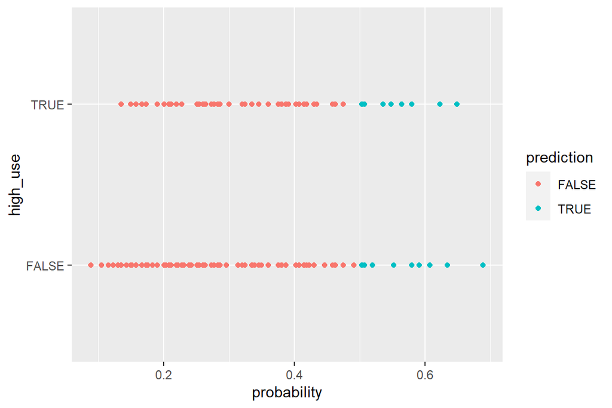

```r
# initialize a plot of 'high_use' versus 'probability' in 'alc'
g <- ggplot(alc, aes(x = probability, y = high_use))

# define the geom as points and draw the plot
g + geom_point(aes(col = prediction))
```

```r
table(high_use = alc$high_use, prediction = alc$prediction) %>% prop.table %>% addmargins
```

```
##         prediction
## high_use      FALSE       TRUE        Sum
##    FALSE 0.65945946 0.04054054 0.70000000
##    TRUE  0.25135135 0.04864865 0.30000000
##    Sum   0.91081081 0.08918919 1.00000000
```

In this table we can see the predictions as proportions. For example, using the given variables it can be correctly predicted about 66 % of the time that a student doesn’t have a high alcohol consumption, and about 4 percent of time high consumption will be predicted when the alcohol consumption is not high.

And finally, calculating the training error:

```r
# define a loss function (mean prediction error)
loss_func <- function(class, prob) {
  n_wrong <- abs(class - prob) > 0.5
  mean(n_wrong)
}

loss_func(class = alc$high_use, prob = alc$probability)
```

```
## [1] 0.2918919
```

This means that about 29 % of the predictions made using this model will be mistaken. This is better than random chance, where half the predictions would be mistaken, but neither is this impressive.

# Clustering And Classification

```r
library(tidyverse)
```

### The data

```r
boston <- MASS::Boston
boston %>% str
```

```
## 'data.frame':    506 obs. of  14 variables:
##  $ crim   : num  0.00632 0.02731 0.02729 0.03237 0.06905 ...
##  $ zn     : num  18 0 0 0 0 0 12.5 12.5 12.5 12.5 ...
##  $ indus  : num  2.31 7.07 7.07 2.18 2.18 2.18 7.87 7.87 7.87 7.87 ...
##  $ chas   : int  0 0 0 0 0 0 0 0 0 0 ...
##  $ nox    : num  0.538 0.469 0.469 0.458 0.458 0.458 0.524 0.524 0.524 0.524 ...
##  $ rm     : num  6.58 6.42 7.18 7 7.15 ...
##  $ age    : num  65.2 78.9 61.1 45.8 54.2 58.7 66.6 96.1 100 85.9 ...
##  $ dis    : num  4.09 4.97 4.97 6.06 6.06 ...
##  $ rad    : int  1 2 2 3 3 3 5 5 5 5 ...
##  $ tax    : num  296 242 242 222 222 222 311 311 311 311 ...
##  $ ptratio: num  15.3 17.8 17.8 18.7 18.7 18.7 15.2 15.2 15.2 15.2 ...
##  $ black  : num  397 397 393 395 397 ...
##  $ lstat  : num  4.98 9.14 4.03 2.94 5.33 ...
##  $ medv   : num  24 21.6 34.7 33.4 36.2 28.7 22.9 27.1 16.5 18.9 ...
```

The dataset has 14 variables that I don’t care to repeat now because I’m sick and you can read about the data [here](https://stat.ethz.ch/R-manual/R-devel/library/MASS/html/Boston.html) anyway.

Creating a correlation plot:

```r
# calculate the correlation matrix and round it
cor_matrix <- cor(boston)

# print the correlation matrix
cor_matrix
```

```
##                crim          zn       indus         chas         nox
## crim     1.00000000 -0.20046922  0.40658341 -0.055891582  0.42097171
## zn      -0.20046922  1.00000000 -0.53382819 -0.042696719 -0.51660371
## indus    0.40658341 -0.53382819  1.00000000  0.062938027  0.76365145
## chas    -0.05589158 -0.04269672  0.06293803  1.000000000  0.09120281
## nox      0.42097171 -0.51660371  0.76365145  0.091202807  1.00000000
## rm      -0.21924670  0.31199059 -0.39167585  0.091251225 -0.30218819
## age      0.35273425 -0.56953734  0.64477851  0.086517774  0.73147010
## dis     -0.37967009  0.66440822 -0.70802699 -0.099175780 -0.76923011
## rad      0.62550515 -0.31194783  0.59512927 -0.007368241  0.61144056
## tax      0.58276431 -0.31456332  0.72076018 -0.035586518  0.66802320
## ptratio  0.28994558 -0.39167855  0.38324756 -0.121515174  0.18893268
## black   -0.38506394  0.17552032 -0.35697654  0.048788485 -0.38005064
## lstat    0.45562148 -0.41299457  0.60379972 -0.053929298  0.59087892
## medv    -0.38830461  0.36044534 -0.48372516  0.175260177 -0.42732077
##                  rm         age         dis          rad         tax    ptratio
## crim    -0.21924670  0.35273425 -0.37967009  0.625505145  0.58276431  0.2899456
## zn       0.31199059 -0.56953734  0.66440822 -0.311947826 -0.31456332 -0.3916785
## indus   -0.39167585  0.64477851 -0.70802699  0.595129275  0.72076018  0.3832476
## chas     0.09125123  0.08651777 -0.09917578 -0.007368241 -0.03558652 -0.1215152
## nox     -0.30218819  0.73147010 -0.76923011  0.611440563  0.66802320  0.1889327
## rm       1.00000000 -0.24026493  0.20524621 -0.209846668 -0.29204783 -0.3555015
## age     -0.24026493  1.00000000 -0.74788054  0.456022452  0.50645559  0.2615150
## dis      0.20524621 -0.74788054  1.00000000 -0.494587930 -0.53443158 -0.2324705
## rad     -0.20984667  0.45602245 -0.49458793  1.000000000  0.91022819  0.4647412
## tax     -0.29204783  0.50645559 -0.53443158  0.910228189  1.00000000  0.4608530
## ptratio -0.35550149  0.26151501 -0.23247054  0.464741179  0.46085304  1.0000000
## black    0.12806864 -0.27353398  0.29151167 -0.444412816 -0.44180801 -0.1773833
## lstat   -0.61380827  0.60233853 -0.49699583  0.488676335  0.54399341  0.3740443
## medv     0.69535995 -0.37695457  0.24992873 -0.381626231 -0.46853593 -0.5077867
##               black      lstat       medv
## crim    -0.38506394  0.4556215 -0.3883046
## zn       0.17552032 -0.4129946  0.3604453
## indus   -0.35697654  0.6037997 -0.4837252
## chas     0.04878848 -0.0539293  0.1752602
## nox     -0.38005064  0.5908789 -0.4273208
## rm       0.12806864 -0.6138083  0.6953599
## age     -0.27353398  0.6023385 -0.3769546
## dis      0.29151167 -0.4969958  0.2499287
## rad     -0.44441282  0.4886763 -0.3816262
## tax     -0.44180801  0.5439934 -0.4685359
## ptratio -0.17738330  0.3740443 -0.5077867
## black    1.00000000 -0.3660869  0.3334608
## lstat   -0.36608690  1.0000000 -0.7376627
## medv     0.33346082 -0.7376627  1.0000000
```

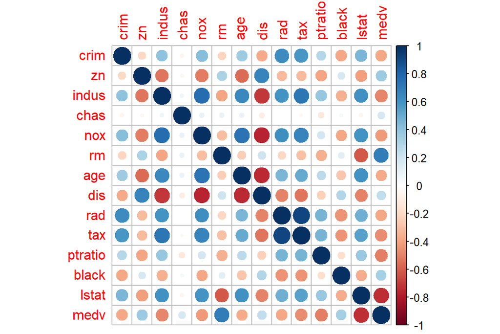

```r
# visualize the correlation matrix
library(corrplot)
corrplot(cor_matrix, method="circle")
```

Here larger circle size and darker color mean higher correlations, with red meaning negative correlation and blue positive. To point out some correlations, lower status of the population (lstat) has high negative correlation with median value of owner-occupied homes (medv), property tax rate (tax) correlates positively with accessibility to radial high ways (rad) and with the proportion of non-retail business acres per town (indus), and distances to to Boston employment centers (dis) correlate negatively with nitrogen oxides concentration (nox).

Next some density plots:

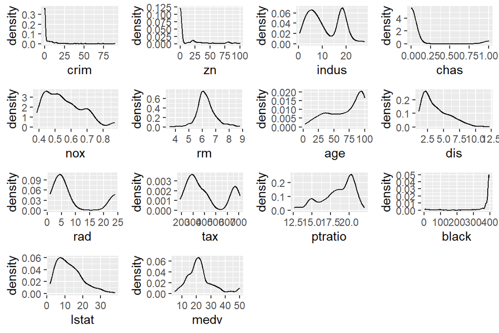

```r
library(cowplot)
my_plots <- lapply(names(boston), function(var_x){
  p <-
    ggplot(boston) +
    aes_string(var_x)

  if(is.numeric(boston[[var_x]])) {
    p <- p + geom_density()

  } else {
    p <- p + geom_bar()
  }
})
plot_grid(plotlist = my_plots)
```

The density plots show that most cities have a low crime rate but it can be tens of times higher in the high crime rate cities.

### Standardizing the data

> *Standardize the dataset and print out summaries of the scaled data. How did the variables change? Create a categorical variable of the crime rate in the Boston dataset (from the scaled crime rate). Use the quantiles as the break points in the categorical variable. Drop the old crime rate variable from the dataset. Divide the dataset to train and test sets, so that 80% of the data belongs to the train set. **(0-2 points)***

```r
# center and standardize variables
scaled <- boston %>% scale
scaled %>% class # class of the scaled data
```

```
## [1] "matrix" "array"
```

```r
scaled <- scaled %>% as.data.frame() # changing to data frame
scaled %>% summary
```

```
##       crim                 zn               indus              chas
##  Min.   :-0.419367   Min.   :-0.48724   Min.   :-1.5563   Min.   :-0.2723
##  1st Qu.:-0.410563   1st Qu.:-0.48724   1st Qu.:-0.8668   1st Qu.:-0.2723
##  Median :-0.390280   Median :-0.48724   Median :-0.2109   Median :-0.2723
##  Mean   : 0.000000   Mean   : 0.00000   Mean   : 0.0000   Mean   : 0.0000
##  3rd Qu.: 0.007389   3rd Qu.: 0.04872   3rd Qu.: 1.0150   3rd Qu.:-0.2723
##  Max.   : 9.924110   Max.   : 3.80047   Max.   : 2.4202   Max.   : 3.6648
##       nox                rm               age               dis
##  Min.   :-1.4644   Min.   :-3.8764   Min.   :-2.3331   Min.   :-1.2658
##  1st Qu.:-0.9121   1st Qu.:-0.5681   1st Qu.:-0.8366   1st Qu.:-0.8049
##  Median :-0.1441   Median :-0.1084   Median : 0.3171   Median :-0.2790
##  Mean   : 0.0000   Mean   : 0.0000   Mean   : 0.0000   Mean   : 0.0000
##  3rd Qu.: 0.5981   3rd Qu.: 0.4823   3rd Qu.: 0.9059   3rd Qu.: 0.6617
##  Max.   : 2.7296   Max.   : 3.5515   Max.   : 1.1164   Max.   : 3.9566
##       rad               tax             ptratio            black
##  Min.   :-0.9819   Min.   :-1.3127   Min.   :-2.7047   Min.   :-3.9033
##  1st Qu.:-0.6373   1st Qu.:-0.7668   1st Qu.:-0.4876   1st Qu.: 0.2049
##  Median :-0.5225   Median :-0.4642   Median : 0.2746   Median : 0.3808
##  Mean   : 0.0000   Mean   : 0.0000   Mean   : 0.0000   Mean   : 0.0000
##  3rd Qu.: 1.6596   3rd Qu.: 1.5294   3rd Qu.: 0.8058   3rd Qu.: 0.4332
##  Max.   : 1.6596   Max.   : 1.7964   Max.   : 1.6372   Max.   : 0.4406
##      lstat              medv
##  Min.   :-1.5296   Min.   :-1.9063
##  1st Qu.:-0.7986   1st Qu.:-0.5989
##  Median :-0.1811   Median :-0.1449
##  Mean   : 0.0000   Mean   : 0.0000
##  3rd Qu.: 0.6024   3rd Qu.: 0.2683
##  Max.   : 3.5453   Max.   : 2.9865
```

The scale() function substracts each value with the mean of the variable and divides them with the standard deviation of the variable. This way the mean of the scaled data becomes 0 and the variation better comparable.

### Converting crime rates into categorical variable split by quantiles

```r
# original crime variable in the scaled data set
scaled$crim %>% summary
```

```
##      Min.   1st Qu.    Median      Mean   3rd Qu.      Max.
## -0.419367 -0.410563 -0.390280  0.000000  0.007389  9.924110
```

Here are the quantile points for *crim*:

```r
# quantile points
bins <- scaled$crim %>% quantile
bins
```

```
##           0%          25%          50%          75%         100%
## -0.419366929 -0.410563278 -0.390280295  0.007389247  9.924109610
```

These quantile points can be used to create a categorical crime variable:

```r
crime <- scaled$crim %>% cut(
  breaks = bins,
  label = c("low", "med_low", "med_high", "high"),
  include.lowest = TRUE
  )
crime %>% table
```

```
## .
##      low  med_low med_high     high
##      127      126      126      127
```

Now we can drop the old crime rate variable *crim* from the dataset and create a new one with the categorical crime rate variable.

```r
scaled <- scaled %>%
  dplyr::select(-crim) %>% #removing old crime rate variable
  data.frame(crime) #new dataframe with the categorical crime rate variable
```

Finally, I divide the dataset to train and test sets with 80 % of the data in the train set for creating a linear discriminant model and testing it.

```r
n <- scaled %>% nrow # number of rows in the dataset
div <- sample(n, size = n * 0.8) # choosing randomly 80 % of the rows
train <- scaled[div,] # creating train set
test <- scaled[-div,] # creating test set
```

### Linear discriminant analysis

> *Fit the linear discriminant analysis on the train set. Use the categorical crime rate as the target variable and all the other variables in the dataset as predictor variables. Draw the LDA (bi)plot. **(0-3 points)***

```r
# linear discriminant analysis on the train set with crime as target and others as predictor variables
library(MASS)
lda.fit <- lda(crime ~ ., data = train)
lda.fit
```

```
## Call:
## lda(crime ~ ., data = train)
##
## Prior probabilities of groups:
##       low   med_low  med_high      high
## 0.2425743 0.2549505 0.2599010 0.2425743
##
## Group means:
##                  zn      indus         chas        nox          rm        age
## low       0.9071418 -0.9064868 -0.111631099 -0.8734594  0.45626541 -0.8857575
## med_low  -0.1388114 -0.2316224 -0.004759149 -0.5431482 -0.11557817 -0.3223551
## med_high -0.3802515  0.2044296  0.140129052  0.3961500  0.08863988  0.4575117
## high     -0.4872402  1.0171960 -0.031282114  1.0470123 -0.42113930  0.8302651
##                 dis        rad        tax     ptratio       black       lstat
## low       0.8112510 -0.6830354 -0.7597939 -0.40318822  0.38969209 -0.78356869
## med_low   0.3247808 -0.5537049 -0.4934770 -0.08395001  0.31250546 -0.11586963
## med_high -0.4115236 -0.4142004 -0.3090969 -0.27376045  0.06666694  0.06249352
## high     -0.8702304  1.6373367  1.5134896  0.77985517 -0.74655328  0.89270985
##                 medv
## low       0.52954222
## med_low  -0.01655128
## med_high  0.16366988
## high     -0.66193753
##
## Coefficients of linear discriminants:
##                 LD1         LD2         LD3
## zn       0.10473951  0.70367943 -0.99108332
## indus    0.04404122 -0.27665904  0.42989879
## chas    -0.07897605 -0.02310017  0.09464156
## nox      0.38281803 -0.68624175 -1.39485648
## rm      -0.08531787 -0.10387543 -0.12198255
## age      0.23767521 -0.34677754 -0.10293098
## dis     -0.07617167 -0.24175494  0.27236210
## rad      3.17927031  0.88492735  0.10275368
## tax     -0.02720834  0.02406282  0.44184724
## ptratio  0.12311896  0.09599033 -0.43369194
## black   -0.12874821  0.04721452  0.16490309
## lstat    0.20599025 -0.22356087  0.29715276
## medv     0.17490170 -0.35681400 -0.29559873
##
## Proportion of trace:
##    LD1    LD2    LD3
## 0.9451 0.0404 0.0144
```

Plotting the LDA model:

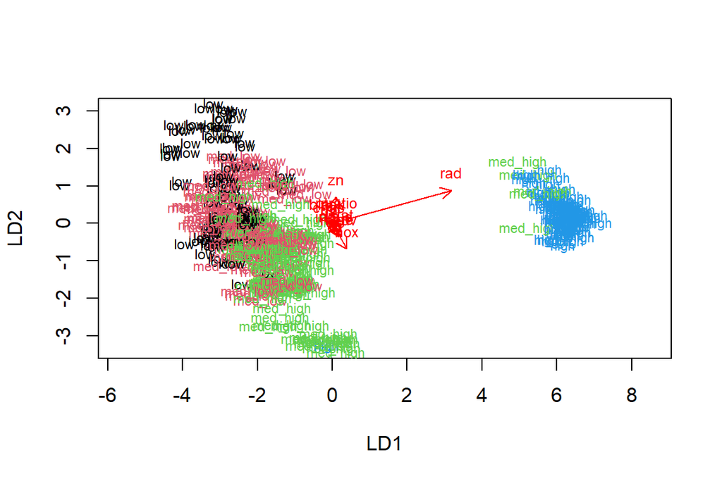

```r
# the function for lda biplot arrows
lda.arrows <- function(x, myscale = 1, arrow_heads = 0.1, color = "red", tex = 0.75, choices = c(1,2)){
  heads <- coef(x)
  arrows(x0 = 0, y0 = 0,
         x1 = myscale * heads[,choices[1]],
         y1 = myscale * heads[,choices[2]], col=color, length = arrow_heads)
  text(myscale * heads[,choices], labels = row.names(heads),
       cex = tex, col=color, pos=3)
}

# target classes as numeric
classes <- train$crime %>% as.numeric

#plotting the results
plot(lda.fit, dimen = 2, col = classes, pch = classes)
lda.arrows(lda.fit, myscale = 1)
```

### Predicting the classes with the LDA model

> *Then predict the classes with the LDA model on the test data. Cross tabulate the results with the crime categories from the test set. Comment on the results. **(0-3 points)***

```r
# saving the correct crime classes from test data
correct_classes <- test$crime
test <- test %>% dplyr::select(-crime) # removing crime from test data

# predicting classes with the test data
lda.pred <- lda.fit %>% predict(newdata=test)

# cross-tabulating the results
table(correct = correct_classes, predicted = lda.pred$class)
```

```
##           predicted
## correct    low med_low med_high high
##   low       18       9        2    0
##   med_low    4      16        3    0
##   med_high   0       9       11    1
##   high       0       0        0   29
```

The model often predicts *med_low* when the correct category is *low* and it correctly predicts the high values the most.

### Investigating the optimal number of clusters

> *Reload the Boston dataset and standardize the dataset (we did not do this in the Exercise Set, but you should scale the variables to get comparable distances). Calculate the distances between the observations. Run k-means algorithm on the dataset. Investigate what is the optimal number of clusters and run the algorithm again. Visualize the clusters (for example with the pairs() or ggpairs() functions, where the clusters are separated with colors) and interpret the results. **(0-4 points)***

I’ll limit the printed variables to just a few to keep them somewhat readable.

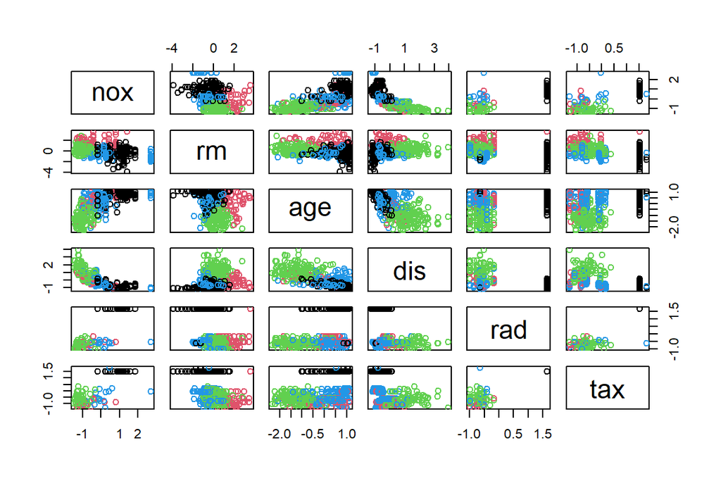

```r
data("Boston")
bost <- Boston %>% scale
# bost %>% dist # calculating distances between observations, although I didn't get what the point of this was

# k-means clustering
km <- kmeans(bost, centers = 4)

# plot the Boston dataset with clusters
pairs(bost[,5:10], col = km$cluster)
```

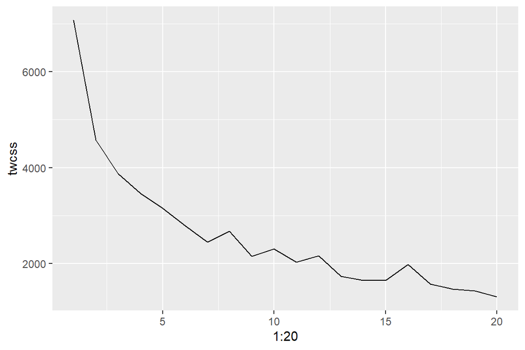

```r
# determining the optimal number of clusters
set.seed(5461873)
twcss <- sapply(1:20, function(k){kmeans(bost, k)$tot.withinss})
qplot(x = 1:20, y = twcss, geom = "line")
```

The exercises of the week guide that the correct number of clusters is when the WCSS drops “dramatically”. I guess that means 2 here. The second choice would be 7, as the decrease is almost linear from 2 to 7.

Rerunning with two clusters:

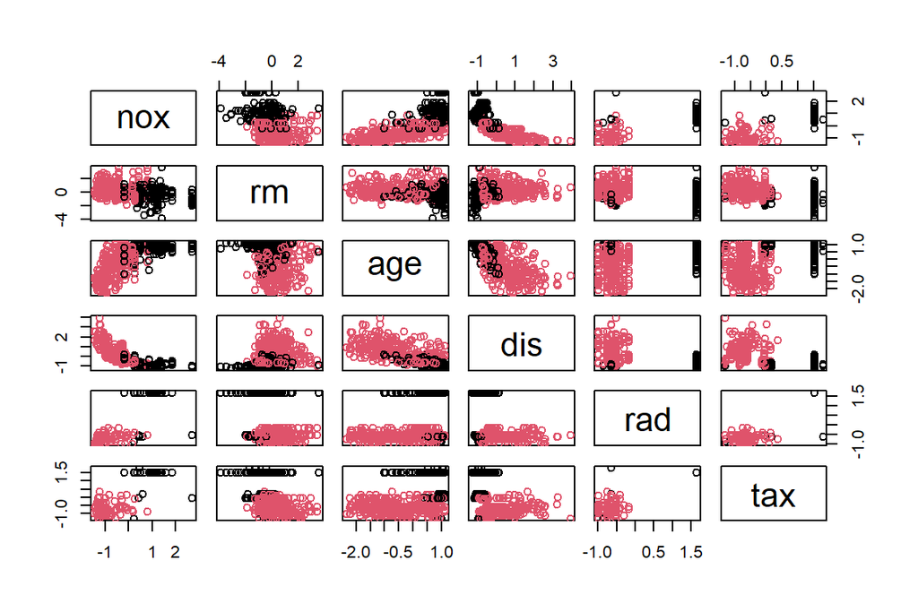

```r
# k-means clustering
km <- kmeans(bost, centers = 2)

# plot the Boston dataset with clusters
pairs(bost[,5:10], col = km$cluster)
```

The clusters seem to have less overlap and be quite separate from each other, so I interpret that reducing the clusters was a good thing.

### LDA using km clusters as target

> **Bonus:** Perform k-means on the original Boston data with some reasonable number of clusters (> 2). Remember to standardize the dataset. Then perform LDA using the clusters as target classes. Include all the variables in the Boston data in the LDA model. Visualize the results with a biplot (include arrows representing the relationships of the original variables to the LDA solution). Interpret the results. Which variables are the most influential linear separators for the clusters? **(0-2 points to compensate any loss of points from the above exercises)**

```r
bonus <- MASS::Boston %>% scale %>% as.data.frame
# k-means clustering
km <- kmeans(bonus, centers = 3)

# LDA using clusters as targets
lda.bonus <- lda(km$cluster ~ ., data = bonus)
lda.bonus
```

```
## Call:
## lda(km$cluster ~ ., data = bonus)
##
## Prior probabilities of groups:
##         1         2         3
## 0.3241107 0.2094862 0.4664032
##
## Group means:
##         crim         zn     indus        chas        nox          rm
## 1  0.8046456 -0.4872402  1.117990  0.01575144  1.1253988 -0.46443119
## 2 -0.4075892  1.5146367 -1.068814 -0.04947434 -0.9962503  0.92400834
## 3 -0.3760908 -0.3417123 -0.296848  0.01127561 -0.3345884 -0.09228038
##           age         dis        rad        tax     ptratio      black
## 1  0.79737580 -0.85425848  1.2219249  1.2954050  0.60580719 -0.6407268
## 2 -1.16762641  1.19486951 -0.5983266 -0.6616391 -0.74378342  0.3538816
## 3 -0.02966623  0.05695857 -0.5803944 -0.6030198 -0.08691245  0.2863040
##        lstat        medv
## 1  0.8719904 -0.68418954
## 2 -0.9480974  0.97889973
## 3 -0.1801190  0.03577844
##
## Coefficients of linear discriminants:
##                 LD1         LD2
## crim     0.03134296 -0.14880455
## zn       0.06381527 -1.22350515
## indus   -0.61086696 -0.10402980
## chas    -0.01953161  0.03579238
## nox     -1.00230143 -0.70464917
## rm       0.16285767 -0.44390394
## age      0.07220634  0.59785382
## dis      0.04270475 -0.45498614
## rad     -0.71987743 -0.02882054
## tax     -0.98285440 -0.70663319
## ptratio -0.22527977 -0.15514668
## black    0.01693595  0.03181845
## lstat   -0.18274033 -0.50122677
## medv     0.02892966 -0.64244841
##
## Proportion of trace:
##    LD1    LD2
## 0.8409 0.1591
```

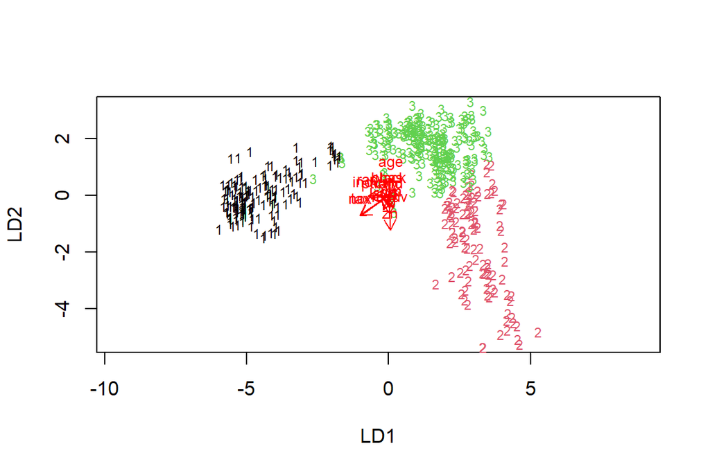

```r
# target classes as numeric
classes <- km$cluster %>% as.numeric

#plotting the results
plot(lda.bonus, dimen = 2, col = classes, pch = classes)
lda.arrows(lda.bonus, myscale = 1)
```

### 3D plots colored by crime classes vs km clusters

> **Super-Bonus:** Run the code below for the (scaled) train data that you used to fit the LDA. The code creates a matrix product, which is a projection of the data points. Adjust the code: add argument color as a argument in the plot_ly() function. Set the color to be the crime classes of the train set. Draw another 3D plot where the color is defined by the clusters of the k-means. How do the plots differ? Are there any similarities? (0-3 points to compensate any loss of points from the above exercises)

```r
model_predictors <- dplyr::select(train, -crime)
# check the dimensions
dim(model_predictors)
```

```
## [1] 404  13
```

```r
dim(lda.fit$scaling)
```

```
## [1] 13  3
```

```r
# matrix multiplication
matrix_product <- as.matrix(model_predictors) %*% lda.fit$scaling
matrix_product <- as.data.frame(matrix_product)
# Next, install and access the plotly package. Create a 3D plot (cool!) of the columns of the matrix product using the code below.
library(plotly)
# plot_ly(x = matrix_product$LD1, y = matrix_product$LD2, z = matrix_product$LD3, type= 'scatter3d', mode='markers', color = train$crime) # causes error in knitting
```

```r
# plot_ly(x = matrix_product$LD1, y = matrix_product$LD2, z = matrix_product$LD3, type= 'scatter3d', mode='markers', color = classes) # causes error in knitting
```

# Dimensionality Reduction Techniques

## Human data

> Show a graphical overview of the data and show summaries of the variables in the data. Describe and interpret the outputs, commenting on the distributions of the variables and the relationships between them. (0-3 points)

```r
library(tidyverse)
human <- read_csv("data/human.csv")
human %>% summary
```

```
##      eduFM            workFM          exp.edu         life.exp
##  Min.   :0.1717   Min.   :0.1857   Min.   : 5.40   Min.   :49.00
##  1st Qu.:0.7264   1st Qu.:0.5984   1st Qu.:11.25   1st Qu.:66.30
##  Median :0.9375   Median :0.7535   Median :13.50   Median :74.20
##  Mean   :0.8529   Mean   :0.7074   Mean   :13.18   Mean   :71.65
##  3rd Qu.:0.9968   3rd Qu.:0.8535   3rd Qu.:15.20   3rd Qu.:77.25
##  Max.   :1.4967   Max.   :1.0380   Max.   :20.20   Max.   :83.50
##       GNI            momdeath         teenmom           repre
##  Min.   :   581   Min.   :   1.0   Min.   :  0.60   Min.   : 0.00
##  1st Qu.:  4198   1st Qu.:  11.5   1st Qu.: 12.65   1st Qu.:12.40
##  Median : 12040   Median :  49.0   Median : 33.60   Median :19.30
##  Mean   : 17628   Mean   : 149.1   Mean   : 47.16   Mean   :20.91
##  3rd Qu.: 24512   3rd Qu.: 190.0   3rd Qu.: 71.95   3rd Qu.:27.95
##  Max.   :123124   Max.   :1100.0   Max.   :204.80   Max.   :57.50
```

```r
human %>% str
```

```
## spec_tbl_df [155 x 8] (S3: spec_tbl_df/tbl_df/tbl/data.frame)
##  $ eduFM   : num [1:155] 1.007 0.997 0.983 0.989 0.969 ...
##  $ workFM  : num [1:155] 0.891 0.819 0.825 0.884 0.829 ...
##  $ exp.edu : num [1:155] 17.5 20.2 15.8 18.7 17.9 16.5 18.6 16.5 15.9 19.2 ...
##  $ life.exp: num [1:155] 81.6 82.4 83 80.2 81.6 80.9 80.9 79.1 82 81.8 ...
##  $ GNI     : num [1:155] 64992 42261 56431 44025 45435 ...
##  $ momdeath: num [1:155] 4 6 6 5 6 7 9 28 11 8 ...
##  $ teenmom : num [1:155] 7.8 12.1 1.9 5.1 6.2 3.8 8.2 31 14.5 25.3 ...
##  $ repre   : num [1:155] 39.6 30.5 28.5 38 36.9 36.9 19.9 19.4 28.2 31.4 ...
##  - attr(*, "spec")=
##   .. cols(
##   ..   eduFM = col_double(),
##   ..   workFM = col_double(),
##   ..   exp.edu = col_double(),
##   ..   life.exp = col_double(),
##   ..   GNI = col_double(),
##   ..   momdeath = col_double(),
##   ..   teenmom = col_double(),
##   ..   repre = col_double()
##   .. )
##  - attr(*, "problems")=<externalptr>
```

The data contains 8 variables and 155 observations.

- eduFM: ratio of females to males with secondary education
- workFM: female to male ratio of labor force participation
- exp.edu: the expected years of education
- life.exp: life expectancy at birth in years
- momdeath: maternal mortality ratio
- teenmom: adolescent birth rate
- repre: percent representation in parlament

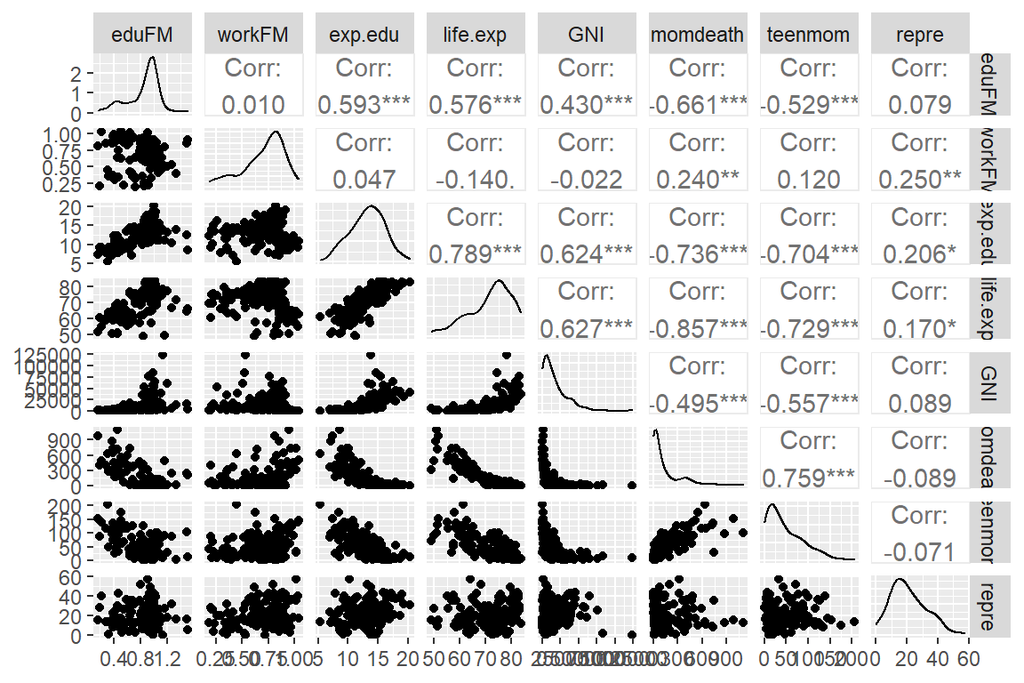

```r
library(GGally)
human %>% ggpairs
```

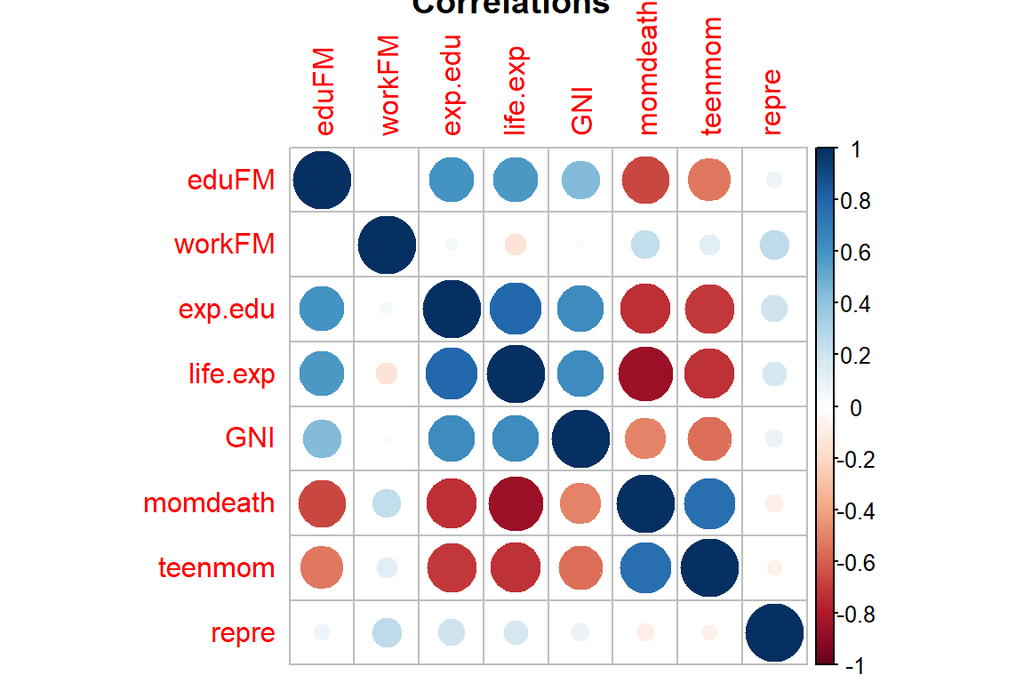

```r
library(corrplot)
cor(human) %>% corrplot(title = "Correlations")
```

### PCA on non-standardized data

> Perform principal component analysis (PCA) on the raw (non-standardized) human data. Show the variability captured by the principal components. Draw a biplot displaying the observations by the first two principal components (PC1 coordinate in x-axis, PC2 coordinate in y-axis), along with arrows representing the original variables. (0-2 points)

```r
pca <- prcomp(human)
pca
```

```
## Standard deviations (1, .., p=8):
## [1] 1.854416e+04 1.855219e+02 2.518701e+01 1.145441e+01 3.766241e+00
## [6] 1.565912e+00 1.912052e-01 1.591112e-01
##
## Rotation (n x k) = (8 x 8):
##                    PC1           PC2           PC3           PC4           PC5
## eduFM    -5.607472e-06  0.0006713951 -3.412027e-05 -2.736326e-04 -0.0022935252
## workFM    2.331945e-07 -0.0002819357  5.302884e-04 -4.692578e-03  0.0022190154
## exp.edu  -9.562910e-05  0.0075529759  1.427664e-02 -3.313505e-02  0.1431180282
## life.exp -2.815823e-04  0.0283150248  1.294971e-02 -6.752684e-02  0.9865644425
## GNI      -9.999832e-01 -0.0057723054 -5.156742e-04  4.932889e-05 -0.0001135863
## momdeath  5.655734e-03 -0.9916320120  1.260302e-01 -6.100534e-03  0.0266373214
## teenmom   1.233961e-03 -0.1255502723 -9.918113e-01  5.301595e-03  0.0188618600
## repre    -5.526460e-05  0.0032317269 -7.398331e-03 -9.971232e-01 -0.0716401914
##                    PC6           PC7           PC8
## eduFM     2.180183e-02  6.998623e-01  7.139410e-01
## workFM    3.264423e-02  7.132267e-01 -7.001533e-01
## exp.edu   9.882477e-01 -3.826887e-02  7.776451e-03
## life.exp -1.453515e-01  5.380452e-03  2.281723e-03
## GNI      -2.711698e-05 -8.075191e-07 -1.176762e-06
## momdeath  1.695203e-03  1.355518e-04  8.371934e-04
## teenmom   1.273198e-02 -8.641234e-05 -1.707885e-04
## repre    -2.309896e-02 -2.642548e-03  2.680113e-03
```

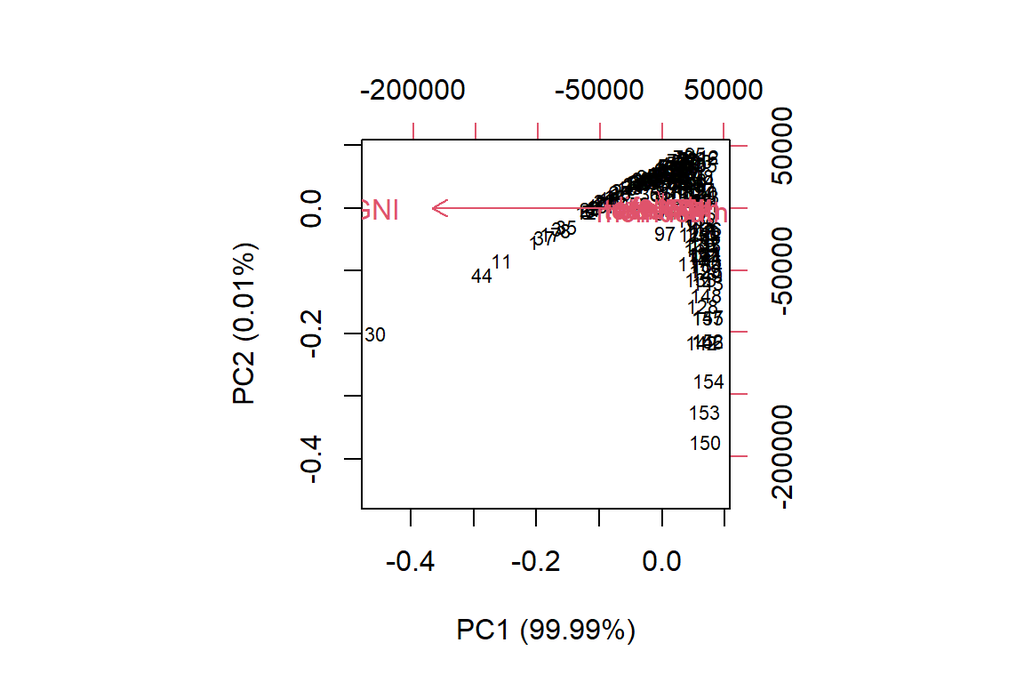

```r
summ <- pca %>% summary
per <- round(100*summ$importance[2, ], digits = 2)
per_lab <- paste0(names(per), " (", per, "%)")
pca %>% biplot(cex = c(0.7, 1), xlab = per_lab[1], ylab = per_lab[2])
```

### PCA on standardized data

> Standardize the variables in the human data and repeat the above analysis. Interpret the results of both analysis (with and without standardizing). Are the results different? Why or why not? Include captions (brief descriptions) in your plots where you describe the results by using not just your variable names, but the actual phenomena they relate to. (0-4 points)

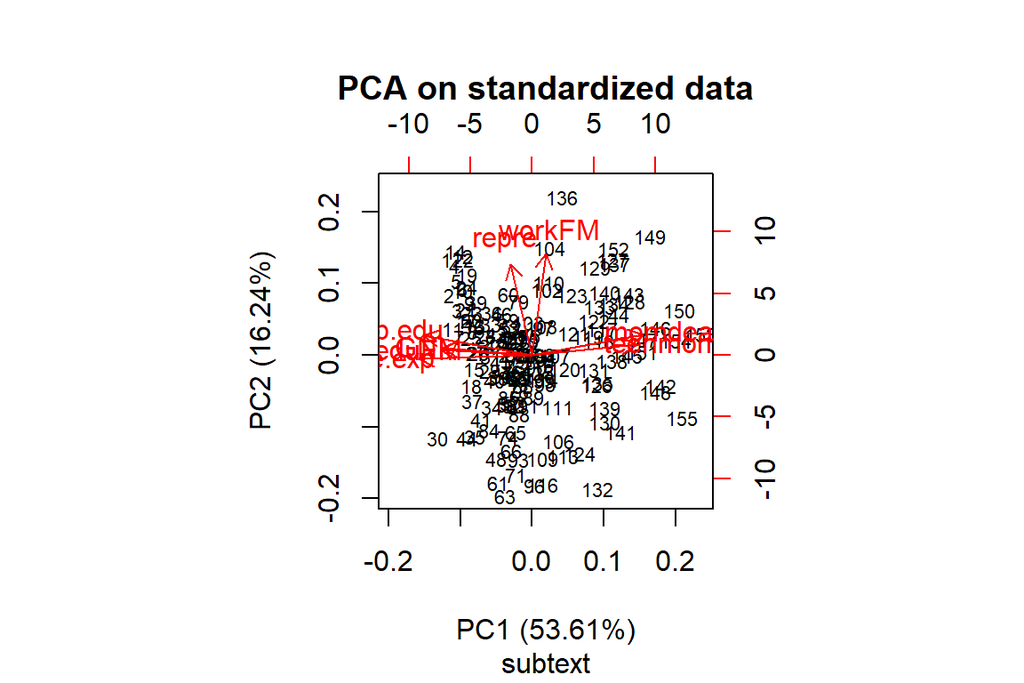

```r
human_std <- scale(human) # standardizing the data
pca_std <- prcomp(human_std) # performing pca

# creating axis labels
s <- pca_std %>% summary
perc <- round(100*s$importance[2, ], digits = 2)
pc_lab <- paste0(names(perc), " (", perc, "%)")

# plotting
pca_std %>% biplot(
  main = "PCA on standardized data",
  cex = c(0.7, 1),
  col = c("black","red"),
  xlab = pc_lab[1],
  ylab = pc_lab[2],
  sub = "subtext")
```

The results are very different. In the non-standardized plot the PC1 explains nearly all the variance, which is caused by the *GNI.* The other variables do not influence the PCs much because of differing scales. The standardized PCA and its plot are a lot more useful as all the variables influence the model.

> Give your personal interpretations of the first two principal component dimensions based on the biplot drawn after PCA on the standardized human data. (0-2 points)

The PC1 explains 53.61 % of the variance and captures well the educational and health-related variables. The PC2 explains 16.24 % of the variance and captures the variables repre and workFM. We can see the same relationships in the correlationplot: the health and educational variables correlate a lot with each other, whereas *repre* and *workFM* do not.